# Multilevel Modelling for Health Researcher

Qing Zhang

2025-04-09

# 1 Random Intercept models

Random intercept models allow us to account for clustering in hierarchical data by introducing cluster-specific intercepts. In this practical, we will explore how to fit and interpret these models using data from the [*Survey of Health, Ageing and Retirement in Europe (SHARE)*](https://share-eric.eu/).

- We will begin by exploring the dataset and considering alternative approaches to handling clustering, including ignoring clustering, using fixed effects, and applying cluster-robust standard errors.
- We will then introduce random intercept models, covering their specification, interpretation, and advantages over alternative methods.
- Finally, we will assess model fit using a likelihood ratio test to determine whether the random intercept approach improves upon a single-level regression model that ignores clustering.

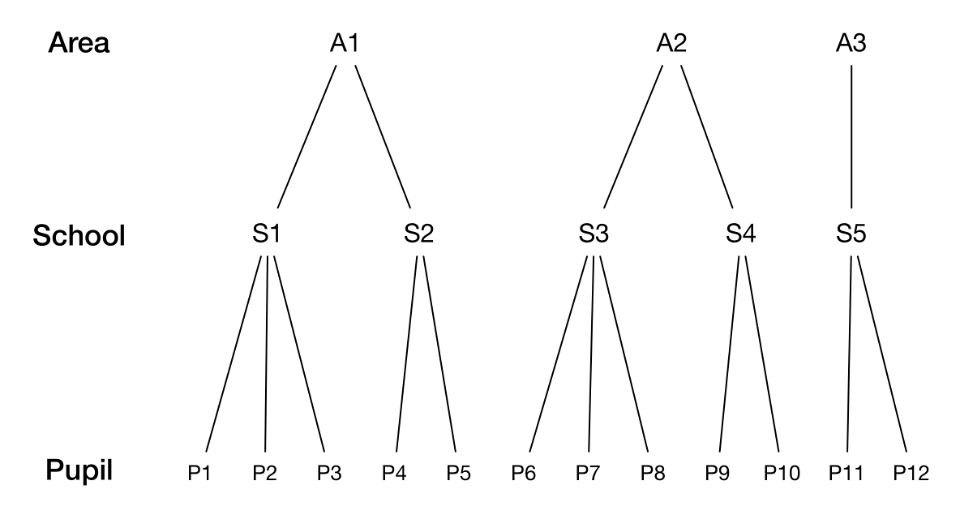

Figure.1 Clustered Data Structure

## 1.1 Data

We will use multilevel data from the **Survey of Health, Ageing and Retirement in Europe (SHARE)**, a longitudinal, cross-national study of individuals aged 50 and older across European countries. SHARE covers a wide range of topics, including health, socio-economic status, and social networks, enabling research on ageing, retirement, and health policy. The dataset has a complex structure with individuals nested within households and countries, making it well-suited for multilevel modelling.

### 1.1.1 Cognitive function

This practical will focus on cognitive ability, measured using a modified version of the Rey Auditory Verbal Learning Test (RAVLT), a widely used measure of memory performance. Respondents are presented with a list of ten common words and asked to recall them immediately (immediate recall, `recall1`) and again after a short delay following an interference task (delayed recall, `recall2`). The total memory score is calculated as the sum of words correctly recalled across both trials, yielding a score ranging from 0 to 20. For details, refer to [this paper](https://www.sciencedirect.com/science/article/pii/S0167629617308299).

This composite measure captures short-term memory and learning ability, making it a robust indicator of cognitive function. Memory performance is particularly relevant in ageing research, as it tends to decline with age and is less susceptible to floor and ceiling effects than alternative cognitive tests, such as verbal fluency. Prior studies have shown a consistent negative association between age and memory scores, with a steeper decline observed around retirement age.

## 1.2 Exploring the data

1. [Click here](https://github.com/QingZhang990806/MLM/blob/main/share.dta) to download the dataset for this practical (`share.dta`).
2. Import the dataset into Stata or R.
3. Explore the available variables (e.g., using `describe` and `sum` commands). How many respondents are there? How many countries and regions?

```r
library(tidyverse)
library(labelled)
library(here)
library(haven)

share <- read_dta("share.dta")
glimpse(share)
```

```
## Rows: 61,794
## Columns: 11
## $ person    <chr> "AT-454475-02", "AT-549610-02", "AT-233122-01", "AT-695942-0…
## $ region    <dbl+lbl> 1, 1, 1, 1, 1, 1, 1, 1, 1, 1, 1, 1, 1, 1, 1, 1, 1, 1, 1,…
## $ country   <dbl+lbl> 11, 11, 11, 11, 11, 11, 11, 11, 11, 11, 11, 11, 11, 11, …
## $ female    <dbl> 1, 1, 0, 0, 1, 1, 0, 0, 1, 0, 0, 0, 0, 1, 1, 1, 1, 1, 0, 0, …
## $ age       <dbl> 55.8, 67.6, 73.8, 50.9, 66.8, 63.8, 76.0, 54.7, 63.4, 64.2, …
## $ education <dbl> 8, 8, 2, 9, 8, 8, 10, 11, 10, 10, 15, 8, 15, 8, 4, 13, 9, 8,…
## $ ends_meet <dbl+lbl> 3, 3, 3, 1, 4, 2, 4, 2, 4, 2, 3, 4, 4, 3, 3, 2, 2, 3, 3,…
## $ cognition <dbl> 14, 10, 10, 9, 10, 9, 7, 7, 10, 9, 7, 10, 2, 6, 8, 5, 14, 8,…
## $ gdp       <dbl> 18.36735, 18.36735, 18.36735, 18.36735, 18.36735, 18.36735, …
## $ log_hinc  <dbl> 9.415501, 10.072345, 11.717118, 9.258357, 9.867815, 10.12589…
## $ partner   <dbl> 1, 1, 1, 0, 0, 1, 0, 0, 1, 1, 1, 1, 1, 0, 1, 1, 1, 0, 0, 1, …
```

Some of the variables have been imported by `haven` as a `labelled` type (e.g., see `map(share, class)`. Let’s convert them to ‘factors’ to show the value labels more easily:

```r
share <-
  share |>
  mutate(across(where(is.labelled), as_factor))
```

And let’s convert `age` to a numeric variable:

```r
share$age <- as.numeric(share$age)
```

## 1.3 Describing hierarchical data

1. `Count` the number of participants per country and region.
2. `Calculate` the mean of cognitive function across the sample as a whole.
3. `Plot` a histogram showing the distribution of cognitive function (again, across the sample as a whole).

```r
share |>
  count(country)
```

```
## # A tibble: 25 × 2
##    country                n
##    <fct>              <int>
##  1 11. Austria         2831
##  2 13. Sweden          1784
##  3 15. Spain           4617
##  4 16. Italy           5264
##  5 17. France          1919
##  6 19. Greece          3773
##  7 20. Switzerland      916
##  8 23. Belgium         6033
##  9 25. Israel          1149
## 10 28. Czech Republic  6608
## # ℹ 15 more rows
```

```r
# How many regions are there?
length(unique(share$region))
```

```
## [1] 355
```

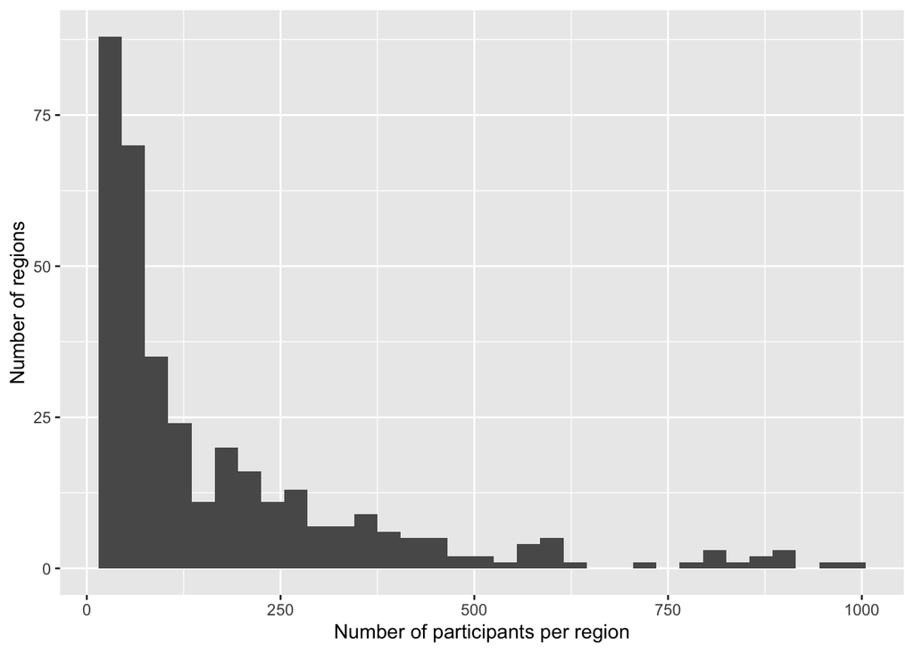

```r
# How many people per region?
share |>
  count(region) |>
  ggplot() +
  aes(x = n) +
  geom_histogram(binwidth = 30) +
  labs(y = "Number of regions",
       x = "Number of participants per region")
```

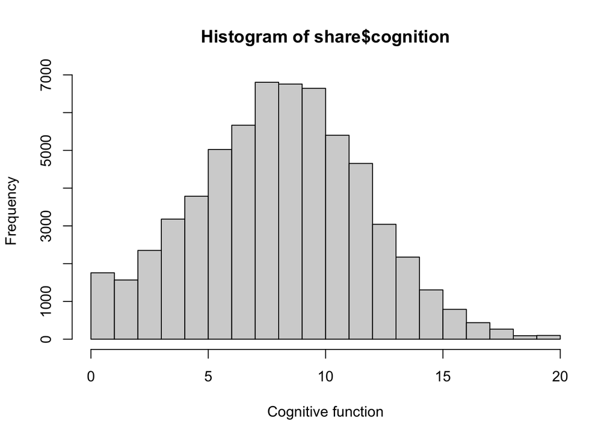

```r
hist(share$cognition,
     breaks = 20,
     xlab = "Cognitive function")
```

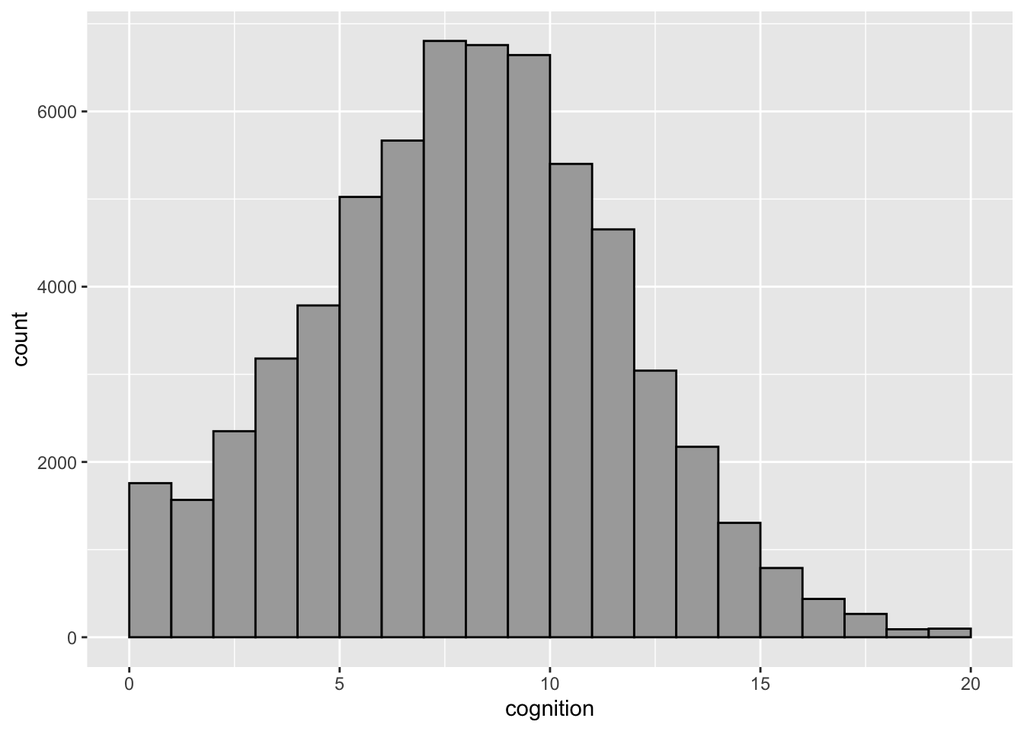

```r
h <- hist(share$cognition, breaks = 20, plot = FALSE)
my_breaks <- h$breaks
share |>
  ggplot() +
  aes(x = cognition) +
  geom_histogram(breaks = my_breaks, fill = "darkgrey", color = "black")
```

4. Repeat steps (b) and (c) to calculate the the mean and plot the distribution of cognition scores, but this time separately by country.

```r
# We can calculate grouped summary statistics using group_by and summarise:
share |>
  group_by(country) |>
  summarise(cognition = mean(cognition)) |>
  arrange(cognition)
```

```
## # A tibble: 25 × 2
##    country       cognition
##    <fct>             <dbl>
##  1 15. Spain          6.74
##  2 53. Cyprus         7.23
##  3 33. Portugal       7.30
##  4 61. Romania        7.44
##  5 59. Malta          7.69
##  6 48. Lithuania      7.70
##  7 29. Poland         7.82
##  8 16. Italy          7.89
##  9 51. Bulgaria       7.96
## 10 35. Estonia        8.16
## # ℹ 15 more rows
```

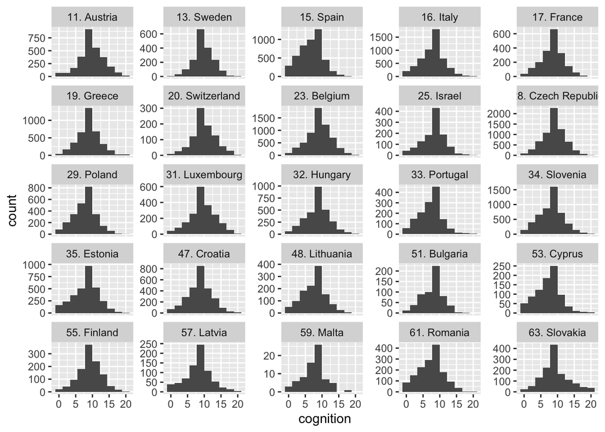

```r
# To create a stratified histogram, we can use facet_wrap:
share |>
  ggplot() +
  aes(x = cognition) +
  geom_histogram(bins = 10) +
  facet_wrap(~ country, scales = "free_y")
```

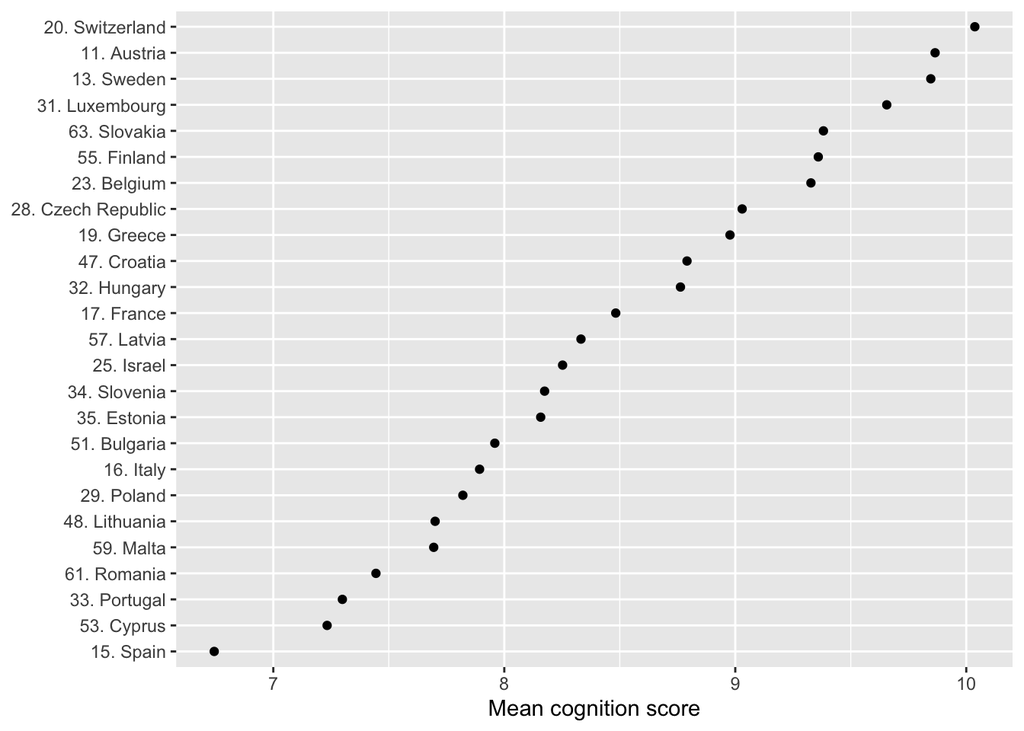

```r
# We can use reorder to rank the y-axis (i.e., countries) based on their mean cognition score:
share |>
  group_by(country) |>
  summarise(cognition = mean(cognition, na.rm = TRUE)) |>
  ggplot() +
  aes(x = cognition,
      y = reorder(country, cognition)) +
  geom_point() +
  theme(axis.title.y = element_blank()) +
  labs(x = "Mean cognition score")
```

### 1.3.1 Grand-mean Centering

Many books and courses recommend that continuous variables used in multilevel models should be grand-mean centred. This transformation subtracts the overall mean (i.e., the average value across all countries) from individual values. Another method of centring is group-mean centring, which subtracts the group-mean (i.e., the average within-country value). The choice of centring technique should be based on substantive research questions (see Enders & Tofighi, 2007; Hofmann & Gavin, 1998; Paccagnella, 2006).

> It is our view that the choice of centering method is intimately linked to one’s substantive research questions, and both grand-mean centring and group-mean centring are appropriate in certain circumstances and are inappropriate in others. *(Enders & Tofighi, 2007, p. 127)*

> There is no single best answer to the question of whether to use group-mean centering or grand-mean centering. The theory and specific questions to be answered should guide the researcher’s choice. *(Wu & Wooldridge, 2005, p. 212)*

For this practical, we will use *grand-mean centring*. This produces a model equivalent to the raw (i.e., un-centred) model but has additional desirable properties:

> In multilevel models, it is especially desirable that the intercepts refer to variable values represented in the data. If we grand-mean centre all variables as explained above, the regression constant will be the predicted mean for persons with the average values for the explanatory variables. The variances of the intercept and the slope can be interpreted as the expected variances for the average person.

> Two main advantages of centring the predictors are: (1) Obtaining estimates of effects that are easier to interpret, so that the statistical results can be related to the theoretical concerns that motivate the research; (2) Removing high correlations between the random intercept and slopes, and high correlations between first- and second-level variables and cross-level interactions.

We will grand-mean centre the variables `age`, `education` (years of education) and `gdp` (Gross Domestic Product):

We can centre a single variable:

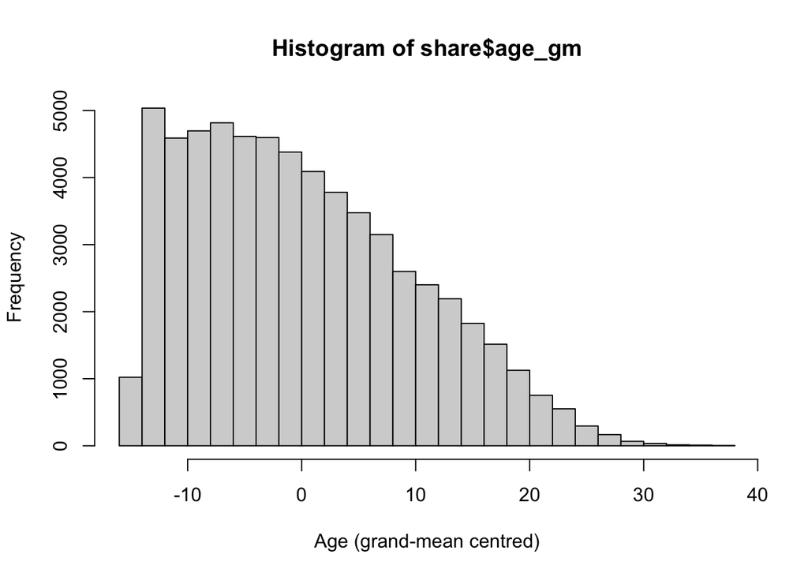

```r
share$age_gm = share$age - mean(share$age, na.rm = TRUE)
hist(share$age_gm,  breaks = 20,
     xlab = "Age (grand-mean centred)")
```

Or multiple variables using `across`:

```r
subtract_mean <- function(x) x - mean(x, na.rm = TRUE)

share <- share |>
  mutate(across(c(age, education, gdp),
    subtract_mean,
    .names = "{.col}_gm"
  ))
```

## 1.4 Other ways of accounting for clustering

Before considering the random intercepts model, we will first consider some other, arguably simpler, techniques for taking into account the clustering of individuals within countries.

**Cluster-robust standard errors**

We can adjust the standard errors from our model to account for clustering by using a cluster-robust estimator.

- In Stata, the `vce(cluster cluster_id)` option relaxes the independence assumption and requires only that the observations be independent across the clusters. (Note that the robust estimator will affect the standard errors only; the coefficients are unchanged). You can read more about this approach in section 20.22 of the Stata manual.
- In R, we can estimate cluster-robust standard errors using the sandwich package. https://sandwich.r-forge.r-project.org/index.html

Below, we fit two regression models, with and without cluster-robust standard errors. We then tabulate the results to compare the intercept term ($\beta_o$) and its standard error.

```r
library(sandwich)
library(lmtest)
```

```r
library(broom)

m1 <- lm(cognition ~ 1, data = share)
m2 <- lm(cognition ~ 1, data = share) |>
  coeftest(vcov = vcovCL,
           type = "HC1",
           cluster = ~ region)

map(list(m1, m2), tidy)
```

```
## [[1]]
## # A tibble: 1 × 5
##   term        estimate std.error statistic p.value
##   <chr>          <dbl>     <dbl>     <dbl>   <dbl>
## 1 (Intercept)     8.53    0.0147      581.       0
##
## [[2]]
## # A tibble: 1 × 5
##   term        estimate std.error statistic p.value
##   <chr>          <dbl>     <dbl>     <dbl>   <dbl>
## 1 (Intercept)     8.53    0.0896      95.2       0
```

What can you say about the $\beta$ coefficient and standard error from the two models?

The $\beta$ coefficients are identical, but the standard errors are larger in the second model that uses cluster-robust standard errors.

**Representing clusters using dummy variables**

This approach uses dummy variables to represent each level-2 unit (in this case, regions) and is sometimes referred to as the “fixed effects” approach. This can be convenient when we have few clusters (e.g., less than 8), but is extremely inefficient with many clusters (e.g., with hundreds of regions in SHARE). This approach also prevents us from exploring cluster-level variances or covariates.

For this section only, we will exclude some of the clusters to avoid the computational burden of fitting a regression model with 354 dummy variables.

```r
share_subset <- share |>
  filter(as.numeric(region) <= 30)
```

In R, we can create dummy variables by ensuring they are coded as factor (e.g., `as_factor`) or by wrapping the variable in `factor` when calling `lm`:

```r
m_fixed <- lm(cognition ~ region, data = share_subset)
```

We can extract the predictions and plot:

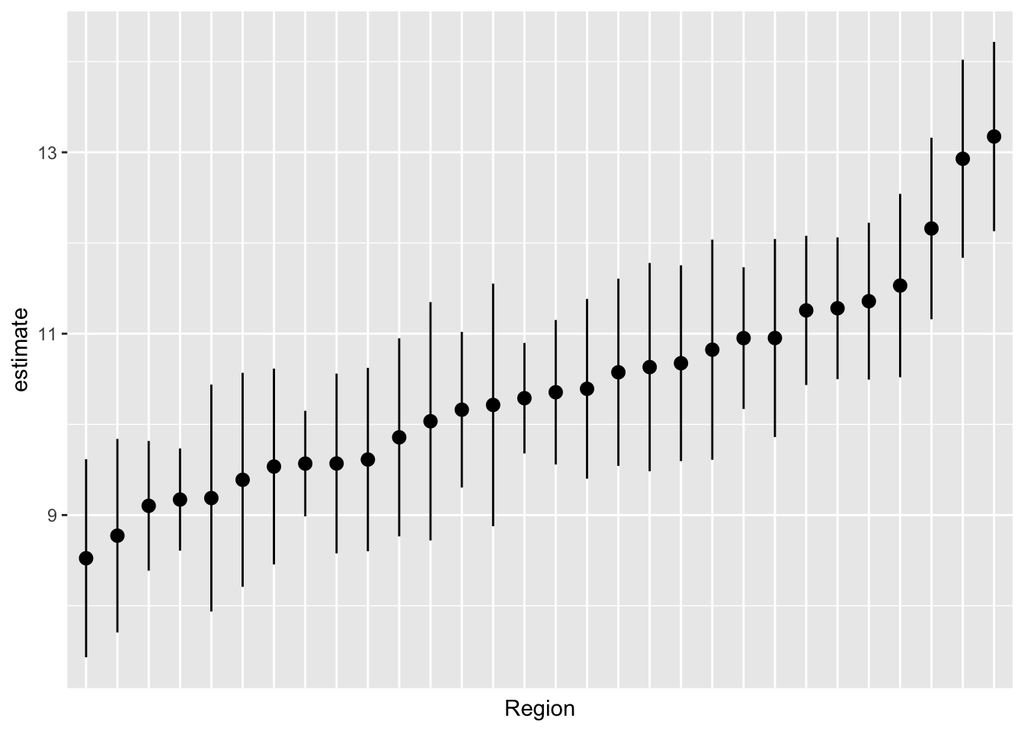

```r
library(marginaleffects)

predictions(m_fixed, by = "region") |>
  ggplot() +
  aes(y = estimate,
      ymin = conf.low,
      ymax = conf.high,
      x = reorder(region, estimate)) +
  geom_pointrange() +
  theme(axis.text.x = element_blank(),
        axis.ticks.x = element_blank()) +
  labs(x = "Region")
```

## 1.5 Random Intercept models

We’ll now fit a random intercept model for cognition that will account for clustering with an region-level random intercept:

$$y_ij = \beta_0 + \mu_j + \epsilon_ij$$

$$\mu_j \sim N(0,\sigma^2_u)$$

$$\epsilon_ij \sim N(\sigma^2_{\epsilon})$$

You should now use the full dataset: For the rest of this practical, you should be working with the full SHARE dataset with 355 regions.

**Specifying the random intercept model** There are several R packages for fitting multilevel models (see this Task Views page on CRAN for an overview). For this practical, we’ll use the `glmmTMB` package.

The function to fit linear multilevel models is `glmmTMB`. The syntax is:

```r
library(glmmTMB)
fit <- glmmTMB(y ~ x1 + x2 + x3 + (1 | cluster_id), data = d)
```

Where:

- `y` is the outcome and `x1`, `x2`, `x3` are predictors.
- `(1 | cluster_id)` specifies a cluster-level random intercept.

For more information on specifying formula for mixed effect models in R, see this vignette(chrome-extension://efaidnbmnnnibpcajpcglclefindmkaj/https://cran.r-project.org/web/packages/lme4/vignettes/lmer.pdf).

## 1.6 Three models

When modelling cognitive function across regions, we’re going to consider three models:

[output not shown]

This latter option (`Partial pooling’) represents one of the principle benefits of multilevel models. We will talk more about this in the next lecture and practical.

**Complete pooling**

We’ll begin by fitting a single model that combines all individuals into a single pool and ignores region clustering.

```r
library(glmmTMB)

complete_pooling <- glmmTMB(cognition ~ 1, data = share)
summary(complete_pooling)
```

```
##  Family: gaussian  ( identity )
## Formula:          cognition ~ 1
## Data: share
##
##       AIC       BIC    logLik -2*log(L)  df.resid
##  335409.4  335427.5 -167702.7  335405.4     61792
##
##
## Dispersion estimate for gaussian family (sigma^2): 13.3
##
## Conditional model:
##             Estimate Std. Error z value Pr(>|z|)
## (Intercept)  8.53330    0.01469     581   <2e-16 ***
## ---
## Signif. codes:  0 '***' 0.001 '**' 0.01 '*' 0.05 '.' 0.1 ' ' 1
```

Note that we could fit this model using `lm`, the R function for linear regression. However, for compatability with later comparisons, we’ll use `glmmTMB`.

Question: How would you interpret this model?

This model has a single intercept, $\beta_0 = 8.53$ , indicating a mean cognitive function score across all regions of 8.53 (out of 20)

Question: Is this a useful model for cognitive function? Why?

Not really. By assuming that cognitive function is constant across regions, this model gives poor estimates of levels of cognitive function within each region.

**No pooling**

Going to the other extreme, let’s fit a seperate model for each region:

```r
library(broom)

results <- share |>
  group_split(region) |>
  map(\(subset) {
    lm(cognition ~ 1, data = subset) |> tidy()
  }) |>
  list_rbind()

results$term <- unique(share$region)

head(results, 10)
```

```
## # A tibble: 10 × 5
##    term      estimate std.error statistic  p.value
##    <fct>        <dbl>     <dbl>     <dbl>    <dbl>
##  1 AT-01-002     9.10     0.307      29.6 2.10e-50
##  2 AT-01-004     9.19     0.474      19.4 6.94e-19
##  3 AT-01-005     9.17     0.251      36.6 9.52e-79
##  4 AT-01-006     9.57     0.258      37.1 1.69e-76
##  5 AT-01-007     8.77     0.461      19.0 1.43e-22
##  6 AT-01-008    10.3      0.325      31.7 4.47e-64
##  7 AT-04-002    11.5      0.562      20.5 2.07e-25
##  8 AT-04-003    11.3      0.413      27.3 5.07e-40
##  9 AT-04-005    12.9      0.528      24.5 4.43e-26
## 10 AT-04-010    10.4      0.536      19.3 1.77e-31
```

Question: How would you interpret these models?

Since we’re fitting a separate model for each region, we get a separate estimate of the intercept ($\beta_0$) and standard error for each country. The intercept varies across regions from 3.47 to 13.17.

Question: Is this a useful model for cognitive function? Why?

Each separate model is an excellent model for the mean of cognitive function within *each region*, but they don’t generalise:

- We can’t apply the region-specific model to other regions, outside our sample.
- By only drawing on information for a region country, these models ignore potentially valuable information from other clusters. This is especially problematic when we have a small number of observations per cluster.

**Partial Pooling**

The random intercepts model offers a useful compromise between the ‘complete pooling’ and ‘no pooling’ models considered above:

- By allowing each cluster to have its own intercept term, this model is better able to capture cluster differences compared to the ‘complete pooling’ model.
- However, unlike ‘no pooling’ model, the random intercepts model is able to borrow information from other clusters when estimating cluster-specific intercepts (through ‘partial pooling’ or ‘shrinkage’). We’ll talk more about shrinkage in the next lecture.

Using the syntax introduced above, we can fit an empty model for cognitive function with region-level random intercepts:

```r
library(glmmTMB)

partial_pooling <- glmmTMB(cognition ~ 1 + (1 | region), data = share)
summary(partial_pooling)
```

```
##  Family: gaussian  ( identity )
## Formula:          cognition ~ 1 + (1 | region)
## Data: share
##
##       AIC       BIC    logLik -2*log(L)  df.resid
##  329445.2  329472.3 -164719.6  329439.2     61791
##
## Random effects:
##
## Conditional model:
##  Groups   Name        Variance Std.Dev.
##  region   (Intercept)  1.722   1.312
##  Residual             11.907   3.451
## Number of obs: 61794, groups:  region, 355
##
## Dispersion estimate for gaussian family (sigma^2): 11.9
##
## Conditional model:
##             Estimate Std. Error z value Pr(>|z|)
## (Intercept)  8.59250    0.07271   118.2   <2e-16 ***
## ---
## Signif. codes:  0 '***' 0.001 '**' 0.01 '*' 0.05 '.' 0.1 ' ' 1
```

Answer the following questions:

1. How many individuals are there? How many regions?
2. What is the overall intercept, $\beta_0$?
3. What is the region-level variance?
4. What is the individual-level variance?
1. There are 61,794 individuals in 355 regions.
2. $\beta_0 = 8.59$
3. $\sigma_\mu^2 = 1.72$
4. $\sigma_\epsilon^2 = 11.91$

**Was it worth it?**

In this section, we’ll use a likelihood ratio test to compare random intercepts model to the single-level model.

The random intercepts model is more complex than the equivalent single-level model that ignores clustering.

1. Single-level, ignoring clustering

$$y_i = \beta_0 + \epsilon_i \\
\epsilon_i \sim \mathcal{N}(0, \sigma^2_\epsilon)$$

2. Random intercepts

$$y_{ij} = \beta_0 + u_j + \epsilon_{ij} \\
u_j \sim \mathcal{N}(0, \sigma^2_u) \\
\epsilon_{ij} \sim \mathcal{N}(0, \sigma^2_\epsilon)$$

What has changed between these models? How many new parameters are there?

The only difference between these models is the introduction of the $\mu_j$ parameter to capture cluster-specific deviations from the overall intercept ($\beta_0$). The line $\mu_j \sim N(0,\sigma_\mu^2)$ reflects our assumption that the $\mu_j$ terms will be normally distributed with a mean of 0 and standard deviation of $\sigma_\mu$ (a variance of $\sigma_\mu^2$).

Therefore, there is one new parameter.

We can test the improvement in model fit between (1) and (2) using a likelihood-ratio test. This compares difference in the Log likelihood between the two models against a $\chi^2$ distribution with $D.F.$ degrees of freedom, where $D.F.$ is the difference in the number of parameter between (1) and (2).

Having fit the `partial_pooling` and `complete_pooling` models above, we can use anova to run the likelihood ratio test:

```r
anova(partial_pooling, complete_pooling)
```

```
## Data: share
## Models:
## complete_pooling: cognition ~ 1, zi=~0, disp=~1
## partial_pooling: cognition ~ 1 + (1 | region), zi=~0, disp=~1
##                  Df    AIC    BIC  logLik deviance  Chisq Chi Df Pr(>Chisq)
## complete_pooling  2 335409 335428 -167703   335405
## partial_pooling   3 329445 329472 -164720   329439 5966.2      1  < 2.2e-16 ***
## ---
## Signif. codes:  0 '***' 0.001 '**' 0.01 '*' 0.05 '.' 0.1 ' ' 1
```

Question: How would you interpret this result?

## 1.7 References

MALMSTROM, M., SUNDQUIST, J. & JOHANSSON, S. E. 1999. Neighborhood environment and self-reported health status: a multilevel analysis. Am J Public Health, 89, 1181-6.

SCHYNS, P. 2002. Wealth Of Nations, Individual Income and Life Satisfaction in 42 Countries: A Multilevel Approach. Social Indicators Research, 60, 5-40.

SJÖBERG, O. 2010. Social Insurance as a Collective Resource: Unemployment Benefits, Job Insecurity and Subjective Well-being in a Comparative Perspective. Social Forces, 88, 1281-1304.

SUBRAMANIAN, S. V., DELGADO, I., JADUE, L., VEGA, J. & KAWACHI, I. 2003. Income inequality and health: multilevel analysis of Chilean communities. J Epidemiol Community Health, 57, 844-8.

# 2 Exploring level-2 residuals

Welcome to the second practical on multilevel modelling. In today’s session:

1. We begin by looking at the level-2 residuals (i.e., the $\mu_j$ terms);
2. We then introduce level-1 (i.e., individual) covariates into the model and plot the fixed slopes.
3. In preparation for the next session on ‘random slopes’, we will explore how associations between education and cognitive function vary by country.

## 2.1 Visualising the level-2 residuals

We will first calculate the level-2 residuals for the empty (i.e., null) random intercept model. Then, we will calculate residuals for a model that includes level-1 covariates.

**Level-2 residuals for the empty random intercept model**

1. **Import** the `share.dta` dataset and create grand mean centred copies of `age` and `education.` Add a `_gm` suffix to the new variables.